# Fisheries example integrating FLR

GMSE: an R package for generalised management strategy evaluation (Supporting Information 5)

A. Bradley Duthie¹³, Jeremy J. Cusack¹, Isabel L. Jones¹, Jeroen Minderman¹, Erlend B. Nilsen², Rocío A. Pozo¹, O. Sarobidy Rakotonarivo¹, Bram Van Moorter², and Nils Bunnefeld¹

[1] Biological and Environmental Sciences, University of Stirling, Stirling, UK [2] Norwegian Institute for Nature Research, Trondheim, Norway [3] alexander.duthie@stir.ac.uk

# Integration and simulation with fisheries

Early development of management strategy evaluation (MSE) models originated in fisheries (Polacheck et al. 1999; Smith, Sainsbury, and Stevens 1999; Sainsbury, Punt, and Smith 2000). Consequently, fisheries-focused software for MSE has been extensively developed, including R libraries that focus on the management of species of exceptional interest, such as the Atlantic Bluefin Tuna (*Thunnus thynnus*) ([ABFTMSE](https://github.com/ICCAT/abft-mse/tree/master/R_package/ABTMSE); Carruthers and Butterworth 2018b; Carruthers and Butterworth 2018a), and Indian Ocean Bigeye (*T. obesus*) and Yellowfin (*T. albacares*) Tuna (MSE-IO-BET-YFT; Kolody and Jumppanen 2016). The largest of all such libraries is the Fisheries Library in R ([FLR](http://www.flr-project.org/)), which includes an extensive collection of tools targeted for fisheries science. The FLR library has been used in over a hundred publications (recent publications include Jardim et al. 2018; Mackinson et al. 2018; Utizi et al. 2018), and includes [an MSE framework](http://www.flr-project.org/doc/An_introduction_to_MSE_using_FLR.html) for evaluating different harvest control rules.

As part of the [ConFooBio](https://sti-cs.org/confoobio/) project, a central focus of GMSE is on simulating the management of animal populations of conservation interest, with a particular emphasis on understanding conservation conflict; further development of GMSE is expected to continue with this as a priority, further building upon the decision-making algorithms of managers and users to better understand how conflict arises and can be managed and mitigated. Hence, GMSE is not intended as a substitute for packages such as [FLR](http://www.flr-project.org/), but the integration of these packages with GMSE could make use of GSME’s current and future simulation capabilities, and particularly the genetic algorithm. Such integration might be possible using the `gmse_apply` function, which allows for custom defined submodels to be used within the GMSE framework, and with default GMSE submodels. Hence, GMSE might be especially useful for modelling the management of fisheries under conditions of increasing competing stakeholder demands and conflicts. We do not attempt such an ambitious project here, but instead show how such a project could be developed through integration of [FLR](http://www.flr-project.org/) and `gmse_apply`.

Here we follow a [Modelling Stock-Recruitment with FLSR](http://www.flr-project.org/doc/Modelling_stock_recruitment_with_FLSR.html) example, then integrate this example with `gmse_apply` to explore the behaviour of a number of simulated fishers who are goal-driven to maximise their own harvest and a manager that aims to keep the fish stocks at a predefined target level. The core concept in GMSE is that manager can only incentivise fishers to harvest less or more by varying the cost of fishing (through e.g. taxes) given a set manager budget; please note that the manager cannot force the fisher to follow any policy. Based on the cost of fishing, the fisher can then given their own budget decide whether to invest in fishing or keep the budget. This concepts represents a nartural resource managmeent and conservation conflict, where one party aims to maximise their livelihood (fisher) and the other aims to keep a population at a sustainable level and prevent it from going extinct. Importantly, the manager does not have full control over fishers but can set policies to incentivise sustainable behaviour. We emphasise that this example is provided only as demonstration of how GMSE can potentially be integrated with already developed fisheries models, and is not intended to make recommendations for management in any population.

# Integrating with the Fisheries Library in R ([FLR](http://www.flr-project.org/))

# Modelling stock-recruitment for the population model

Here we closely follow [a tutorial from the FLR project](http://www.flr-project.org/doc/Modelling_stock_recruitment_with_FLSR.html). To build the stock-recruitment model, the `FLCore` package is needed (Kell et al. 2007).

```r
install.packages(c("FLCore"), repos="http://flr-project.org/R");
```

To start, we need to read in the `FLCore` and GMSE libraries.

```r
library(FLCore);
library(GMSE);
```

For a simplified example in GMSE, we will simulate the process of stock recruitment over multiple time steps using an example stock-recruitment model. The stock-recruitment model describes the relationship between stock-recruitment and spawning stock biomass. The sample that we will work from is a recreation of the North Sea Herring (`nsher`) dataset available in the `FLCore` package (Kell et al. 2007). This data set includes recruitment and spawning stock biomass data between 1960 and 2004. First, we initialise an empty `FLSR` object and read in the recreated herring data files from GMSE, which contains recruitment (`rec.n`) and spawning stock biomass (`ssb.n`)

```r
newFL   <- FLSR(); # Initialises the empty FLSR object
data(nsher_data);  # Called from GMSE library (not from FLCore)
```

The recruitment (`rec.n`) and spawning stock biomass (`ssb.n`) data need to be in the form of a vector, array, matrix to use them with `FLQuant`. We will convert `rec.n` and `ssb.n` into matrices.

```r
rec.m        <- as.matrix(rec.n);
ssb.m        <- as.matrix(ssb.n);
```

We can then construct two `FLQuant` objects, specifying the relevant years and units.

```r
Frec.m       <- FLQuant(rec.m, dimnames=list(age=1, year = 1960:2004));
Fssb.m       <- FLQuant(ssb.m, dimnames=list(age=1, year = 1960:2004));
Frec.m@units <- "10^3";
Fssb.m@units <- "t*10^3";
```

We then place the recruitment and spawning stock biomass data into the `FLSR` object that we created.

```r
rec(newFL)    <- Frec.m;
ssb(newFL)    <- Fssb.m;
range(newFL)  <- c(0, 1960, 0, 2004);
```

The `FLCore` package offers several stock-recruitment models. Here we use a Ricker model of stock recruitment (Ricker 1954), and insert this model into the `FLSR` object below.

```r
model(newFL) <- ricker();
```

Parameters for the Ricker stock-recruitment model can be estimated with maximum likelihood.

```r
newFL <- fmle(newFL);
```

Diagnostic plots, identical to those of the [modelling stock-recruitment tutorial](http://www.flr-project.org/doc/Modelling_stock_recruitment_with_FLSR.html) for the `nsher_ri` example, are shown below.

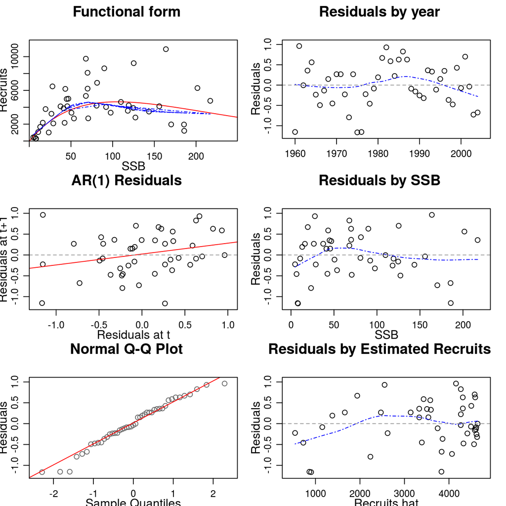

```r
plot(newFL);
```

We now have a working example of a stock-recruitment model, but for our integration with `gmse_apply`, we will want a function that automates the above to simulate the process of updating the stock-recruitment model. We do this using the custom function created below.

```r
update_SR_model <- function(rec_m, ssb_m, years){
    Frec_m       <- FLQuant(rec_m, dimnames=list(age = 1, year = years));
    Fssb_m       <- FLQuant(ssb_m, dimnames=list(age = 1, year = years));
    Frec_m@units <- "10^3";
    Fssb_m@units <- "t*10^3";
    rec(newFL)   <- Frec.m;
    ssb(newFL)   <- Fssb.m;
    range(newFL) <- c(0, years[1], 0, years[length(years)]);
    model(newFL) <- ricker();
    newFL        <- fmle(newFL);
    return(newFL);
}
```

The above function will be used within another custom function to predict the next time step of recruitment.

```r
predict_recruitment <- function(rec_m, ssb_m, years, new_ssb){
    newFL <- update_SR_model(rec_m, ssb_m, years);
    a     <- params(newFL)[[1]] # Extract 'a' parameter of the Ricker model
    b     <- params(newFL)[[2]] # Extract 'b' parameter of the Ricker model
    rec   <- a * new_ssb * exp(-b * new_ssb); # Predict the new recruitment
    return(rec)
}
```

In `gmse_apply`, we will use the `predict_recruitment` function above as the resource (i.e., operational) model. The `new_ssb` reads in the new spawning stock biomass, which will be calculated from the built-in GMSE `user` model.

# Integrating `predict_recruitment` with `gmse_apply`

The [FLR project](http://www.flr-project.org/) includes libraries that can be used to [perform a management strategy evaluation](http://www.flr-project.org/doc/An_introduction_to_MSE_using_FLR.html) (MSE) under fisheries-focused observation, manager, and user models. We will not recreate [this approach](http://www.flr-project.org/doc/An_introduction_to_MSE_using_FLR.html), or integrate any other submodels into GMSE as was done for the population model above, although such integration of submodels should be possible using similar techniques. Our goal here is to instead show how the `predict_recruitment` model created above can be integrated with `gmse_apply`, which can then make use of the genetic algorithm to predict the fishers’ behaviour.

We will use a custom observation model, which will simply estimate recruitment with some fixed error.

```r
obs_ssb <- function(resource_vector){
    obs_err <- rnorm(n = 1, mean = 0, sd = 100);
    the_obs <- resource_vector + obs_err;
    return(the_obs);
}
```

Hence, we can now feed the data from `rec.m` and `ssb.m` through `predict_recruitment`, which will return a value for new recruitment, and this new value can in turn be fed into `obs_ssb` to predict recruitment with some error. We also need a new spawning stock biomass `new_ssb`, which we can just initialise with the biomass from the last year in `ssb.m`

```r
ssb_ini <- ssb.m[length(ssb.m)];
new_rec <- predict_recruitment(rec_m = rec.m, ssb_m = ssb.m, years = 1960:2004,
                               new_ssb = ssb_ini);
obs_rec <- obs_ssb(new_rec);
```

```r
yrspan       <- 1960:2004;
rec.m        <- as.matrix(rec.n);
ssb.m        <- as.matrix(ssb.n);

sim <- gmse_apply(res_mod = predict_recruitment, obs_mod = obs_ssb,
                  rec_m = rec.m, ssb_m = ssb.m, years = yrspan,
                  new_ssb = ssb_ini, manage_target = 5000, stakeholders = 10,
                  manager_budget = 10000);
print(sim);
```

```
## $resource_results
## [1] 3835
##
## $observation_results
## [1] 3917.172
##
## $manager_results
##          resource_type scaring culling castration feeding help_offspring
## policy_1             1      NA     446         NA      NA             NA
##
## $user_results
##         resource_type scaring culling castration feeding help_offspring
## Manager             1      NA       0         NA      NA             NA
## user_1              1      NA       2         NA      NA             NA
## user_2              1      NA       2         NA      NA             NA
## user_3              1      NA       2         NA      NA             NA
## user_4              1      NA       2         NA      NA             NA
## user_5              1      NA       2         NA      NA             NA
## user_6              1      NA       2         NA      NA             NA
## user_7              1      NA       2         NA      NA             NA
## user_8              1      NA       2         NA      NA             NA
## user_9              1      NA       2         NA      NA             NA
## user_10             1      NA       2         NA      NA             NA
##         tend_crops kill_crops
## Manager         NA         NA
## user_1          NA         NA
## user_2          NA         NA
## user_3          NA         NA
## user_4          NA         NA
## user_5          NA         NA
## user_6          NA         NA
## user_7          NA         NA
## user_8          NA         NA
## user_9          NA         NA
## user_10         NA         NA
```

The resource and observation results above are interpreted in terms of recruitment, while the manager results are interpreted in terms of the cost of harvesting a unit of spawning stock biomass and the user results are interpreted in terms of how much biomass was harvested. Note in the run of `gmse_apply` that the arguments for our custom resource and observation models (`predict_recruitment` and `obs_ssb`, respectively) are read directly in as arguments of `gmse_apply` itself. The `gmse_apply` function will figure out which subfunctions custom arguments should go to, then update these arguments as needed over the course of a single run of `gmse_apply`.

# Simulation with `gmse_apply` over multiple time steps

We are now ready to loop the `gmse_apply` function over multiple time steps. To do this, we will update the `rec.m` and `ssb.m` matrices after each time step, simulating 20 years into the future. The population model `predict_recruitment` will use these data to dynamically update parameters of the Ricker model, as might occur in an empirical fishery that is being monitored. We will use the results from the observation model to update recruitment for the new year in `rec.m`. For simplicity, spawning stock biomass prior to harvest will be randomly sampled from a value in last 10 years (i.e., from `ssb.m` between 1994 and 2004), but more realistic models could relate this spawning stock biomass to recruitment and environmental variables from a prevoius year; spawning stock biomass will be decreased after harvest based on user actions. The GMSE initialisation and simulation is below.

```r
# This code initialises the simulation -----------------------------------------
yrspan       <- 1960:2004;
rec.m        <- as.matrix(rec.n);
ssb.m        <- as.matrix(ssb.n);
ssb_ini      <- ssb.m[length(ssb.m)];
sim_old      <- gmse_apply(res_mod = predict_recruitment, obs_mod = obs_ssb,
                           rec_m = rec.m, ssb_m = ssb.m, years = yrspan,
                           new_ssb = ssb_ini, manage_target = 3500,
                           stakeholders = 10, manager_budget = 10000,
                           get_res = "Full");
# The code below simulates 20 time steps ---------------------------------------
sim_sum  <- matrix(data = NA, nrow = 20, ncol = 6); # Hold results here
for(time_step in 1:20){
    # Update the relevant parameter values as necessary -----------------------
    rand_ssb        <- sample(x = ssb.m[35:45], size = 1);
    harvest         <- sum(sim_old$basic_output$user_results[,3]);
    new_rec_m       <- c(sim_old$rec_m, sim_old$observation_vector);
    new_ssb_m       <- c(sim_old$ssb_m, rand_ssb - harvest);
    sim_old$rec_m   <- matrix(data = new_rec_m, nrow = 1);
    sim_old$ssb_m   <- matrix(data = new_ssb_m, nrow = 1);
    sim_old$years   <- c(sim_old$years, time_step + 2004);
    sim_old$new_ssb <- sim_old$ssb_m[length(sim_old$ssb_m)];
    # Run a new simulation in the loop: custom functions are always specified -
    sim_new  <- gmse_apply(get_res = "Full", old_list = sim_old,
                           res_mod = predict_recruitment, obs_mod = obs_ssb);
    # Record the results in sim_sum -------------------------------------------
    sim_sum[time_step, 1] <- time_step + 2004;
    sim_sum[time_step, 2] <- sim_new$basic_output$resource_results[1];
    sim_sum[time_step, 3] <- sim_new$basic_output$observation_results[1];
    sim_sum[time_step, 4] <- sim_new$basic_output$manager_results[3];
    sim_sum[time_step, 5] <- harvest;
    sim_sum[time_step, 6] <- sim_new$new_ssb;
    # Redefine the old list --------------------------------------------------
    sim_old               <- sim_new;
}
colnames(sim_sum) <- c("Year", "Recruitment", "Recruit_estim", "Harvest_cost",
                         "Harvested", "SSB");
print(sim_sum);
```

```
##       Year Recruitment Recruit_estim Harvest_cost Harvested      SSB
##  [1,] 2005        4647      4787.569          447        20 105.2627
##  [2,] 2006        4336      4192.942          485        20 150.1926
##  [3,] 2007        4491      4690.161          531        20 135.9025
##  [4,] 2008        4082      4092.394          520        10  60.6639
##  [5,] 2009        4082      3926.359          528        10  60.6639
##  [6,] 2010        2994      2859.454          478        10  34.8673
##  [7,] 2011        2347      2311.545          431        20  24.8673
##  [8,] 2012        2399      2376.546          492        20  25.5913
##  [9,] 2013        4647      4765.972          500        20 105.2627
## [10,] 2014        2799      2673.883          531        19  31.6133
## [11,] 2015        4339      4229.587          588        10  71.3340
## [12,] 2016        4339      4228.873          559        10  71.3340
## [13,] 2017        3035      3196.864          490        10  35.5913
## [14,] 2018        2919      2966.339          488        20  33.5966
## [15,] 2019        4101      4038.284          508        20  61.3340
## [16,] 2020        3447      3437.060          491        10  43.5966
## [17,] 2021        2399      2501.331          493        20  25.5913
## [18,] 2022        4085      4076.139          471        20  60.7603
## [19,] 2023        2919      2798.141          524        20  33.5966
## [20,] 2024        4387      4528.852          484        10 145.9025
```

The above output from `sim_sum` reports the recruitment (resource or operational model), recruitment estimate (observation error model), management set harvest cost (harvest control model), user harvested numbers (implementation model) and spawning stock biomass (SSB) simulation results. This example simulation demonstrates the ability of GMSE to integrate with fisheries libraries such as [FLR](http://www.flr-project.org/) through `gmse_apply`. In addition to being a useful wrapping function for MSE submodels, `gmse_apply` can therefore be used to take advantage of the genetic algorithm in the GMSE default manager and user models. This flexibility will be retained in future versions of `gmse_apply`, allowing custom resource and observation models that are built for specific systems to be integrated with an increasingly complex genetic algorithm simulating various aspects of human decision-making.

# Conclusions

GMSE is a general, flexible, tool for simulating the management of resources under situations of uncertainty and conflict. Management Strategy Evaluation (Bunnefeld, Hoshino, and Milner-Gulland 2011; Punt et al. 2016), the framework upon which GMSE is based, had its origin in fisheries management (Polacheck et al. 1999; Smith, Sainsbury, and Stevens 1999; Sainsbury, Punt, and Smith 2000), and here we showed one example of how GMSE could be integrated with the core package of the [Fisheries Library in R](http://www.flr-project.org/).

Future versions of GMSE will continue to be open-source and developed to avoid unecessary dependencies (GMSE v.0.4.0.3 requires only base R). Key goals including (1) providing highly general and useful default `resource`, `observation`, `manager`, and `user` submodels for a variety of MSE modelling tasks, (2) keeping these submodels highly modular so that they can be developed in isolation given standardised data structures, and (3) allowing these modular submodels to be integrated with custom defined submodels as flexibly as possible using `gmse_apply`. Contributions in line with these goals, and suggestions for new features, can be made on [GitHub](https://github.com/bradduthie/gmse).

Bunnefeld, Nils, Eriko Hoshino, and Eleanor J Milner-Gulland. 2011. “Management strategy evaluation: A powerful tool for conservation?” *Trends in Ecology and Evolution* 26 (9): 441–47. doi:10.1016/j.tree.2011.05.003.

Carruthers, T, and D Butterworth. 2018a. “ABT-MSE : An R package for atlantic bluefin tuna management strategy evaluation.” *Collective Volume of Scientific Papers ICCAT* 74 (6): 3553–9.

———. 2018b. “Performance of example management procedures for atlantic bluefin tuna.” *Collective Volume of Scientific Papers ICCAT* 73 (6): 3542–52.

Jardim, Ernesto, Margit Eero, Alexandra Silva, Clara Ulrich, Lionel Pawlowski, Isabel Riveiro, Steven J Holmes, et al. 2018. “Testing spatial heterogeneity with stock assessment models.” *PLoS One* 13: e0190891. doi:10.1371/journal.pone.0190791.

Kell, L T, I Mosqueira, P Grosjean, Jean-Marc Fromentin, D Garcia, R Hillary, E Jardim, et al. 2007. “FLR: an open-source framework for the evaluation and development of management strategies.” *ICES Journal of Marine Science* 64 (4): 640–46. https://mail.google.com/mail/u/0/?ui=2{\&}pli=1{\%}5Cnpapers2://publication/doi/10.1093/icesjms/fsm012.

Kolody, Dale, and Paavo Jumppanen. 2016. “IOTC Yellowfin and Bigeye Tuna Management Strategy Evaluation: Phase 1 Technical Support Project Final Report.” June. CSIRO: Oceans & Atmosphere.

Mackinson, Steven, Mark Platts, Clement Garcia, and Christopher Lynam. 2018. “Evaluating the fishery and ecological consequences of the proposed North Sea multi-annual plan.” *PLoS One* 13: e0190015. doi:10.1371/journal.pone.0190015.

Polacheck, T, N L Klaer, C Millar, and A L Preece. 1999. “An initial evalutaion of management strategies for the southern bluefin tuna fishery.” *ICES Journal of Marine Science* 56 (6): 811–26. doi:10.1006/jmsc.1999.0554.

Punt, André E, Doug S Butterworth, Carryn L de Moor, José A A De Oliveira, and Malcolm Haddon. 2016. “Management strategy evaluation: Best practices.” *Fish and Fisheries* 17 (2): 303–34. doi:10.1111/faf.12104.

Ricker, W E. 1954. “Stock and recruitment.” *Journal of the Fisheries Board of Canada* 11 (5): 559–623.

Sainsbury, Keith J, André E Punt, and Anthony DM Smith. 2000. “Design of operational management strategies for achieving fishery ecosystem objectives.” *ICES Journal of Marine Science* 57 (3): 731–41. doi:10.1006/jmsc.2000.0737.

Smith, A D M, K J Sainsbury, and R A Stevens. 1999. “Implementing effective fisheries-management systems – management strategy evaluation and the Australian partnership approach.” *ICES Journal of Marine Science* 56 (6): 967–79. doi:10.1006/jmsc.1999.0540.

Utizi, Kizzi, Emilio Notti, Antonello Sala, Alessandro Buzzi, Ilaria Rodella, Umberto Simeoni, and Corinne Corbau. 2018. “Impact assessment of EMFF measures on Good Environmental Status (GES) as defined by Italy.” *Marine Policy* 88. Elsevier Ltd: 248–60. doi:10.1016/j.marpol.2017.12.003.